# Exercício Computacional I

Anderson Ganhara

6/20/2020

Contexto do problema: Temos o objetivo de construir um modelo preditivo de ML baseado em Redes Neurais Artificiais (RNAs) que seja capaz de realizar predições dos valores medianos de preços das casas em uma região suburbana de Boston, EUA. Tal como no caso da regressão linear, a variável a ser predita consiste em um valor numérico que representa o preço mediano das casas. Para cada uma das observações, temos diversas variáveis de entrada. Logo, podemos buscar a solução para esse problema usando diferentes técnicas de Machine Learning: nesse caso iremos construir, treinar e testar uma rede neural artificial para fazer as predições. O pacote neuralnet pode ser usado para construirmos o modelo de RNA. Na linguagem R podemos usar: install.packages(“neuralnet”) library(neuralnet) Dataset: Os dados estão fornecidos na forma de tabela (.xlsx e .csv) retratado pelo dataset Boston, presente na biblioteca MASS do software R que apresenta os valores das casas (Median value of owner-occupied homes) em 506 vizinhanças da cidade de Boston. Os dados que acompanham o valor mediano dos preços das casas consistem em indicadores de condições socioeconômicas, ambientais, instalações educacionais e alguns outros fatores semelhantes. No ambiente R, o comando ?Boston fornece informações sobre cada uma das features. Ao todo, são 13 features e uma variável resposta, denotada como medv (preço mediano da casa), baseada em $1,000 dólares. De forma específica, no conjunto de variáveis explanatórias (i.e., características), temos doze (12) variáveis numéricas e uma (1) variável categórica, que no caso pode assumir 0 (zero) ou 1 (um). Com isso, a planilha de dados apresenta 506 linhas (exemplos de treinamento) e 14 colunas (features). Abaixo, estão colocadas cada uma das variáveis características do dataset e seu respectivo significado: • CRIM: per capita crime rate by town • ZN: proportion of residential land zoned for lots over 25,000 sq.ft. • INDUS: proportion of non-retail business acres per town • CHAS: Charles River dummy variable (= 1 if tract bounds river; 0 otherwise) • NOX: nitric oxides concentration (parts per 10 million) • RM: average number of rooms per dwelling • AGE: proportion of owner-occupied units built prior to 1940 • DIS: weighted distances to five Boston employment centres • RAD: index of accessibility to radial highways • TAX: full-value property-tax rate per 10,000 • PTRATIO: pupil-teacher ratio by town • B: 1000(Bk −0.63) 2 where Bk is the proportion of blacks by town • LSTAT: % lower status of the population • TARGET: Median value of owner-occupied homes in $1000’s Abaixo, seguem os itens que devemos solucionar, visando alcançar o objetivo deste exercício:

```r
library(MASS)
library(neuralnet)
library(caTools)
library(ggplot2)
library(plotly)
library(tidyverse)
dataset <- Boston
```

• Questões Avaliativas

– 1) Faça a exploração dos dados bem como síntese sobre suas principais variáveis explanatórias.

```r
str(dataset)
```

```
## 'data.frame':    506 obs. of  14 variables:
##  $ crim   : num  0.00632 0.02731 0.02729 0.03237 0.06905 ...
##  $ zn     : num  18 0 0 0 0 0 12.5 12.5 12.5 12.5 ...
##  $ indus  : num  2.31 7.07 7.07 2.18 2.18 2.18 7.87 7.87 7.87 7.87 ...
##  $ chas   : int  0 0 0 0 0 0 0 0 0 0 ...
##  $ nox    : num  0.538 0.469 0.469 0.458 0.458 0.458 0.524 0.524 0.524 0.524 ...
##  $ rm     : num  6.58 6.42 7.18 7 7.15 ...
##  $ age    : num  65.2 78.9 61.1 45.8 54.2 58.7 66.6 96.1 100 85.9 ...
##  $ dis    : num  4.09 4.97 4.97 6.06 6.06 ...
##  $ rad    : int  1 2 2 3 3 3 5 5 5 5 ...
##  $ tax    : num  296 242 242 222 222 222 311 311 311 311 ...
##  $ ptratio: num  15.3 17.8 17.8 18.7 18.7 18.7 15.2 15.2 15.2 15.2 ...
##  $ black  : num  397 397 393 395 397 ...
##  $ lstat  : num  4.98 9.14 4.03 2.94 5.33 ...
##  $ medv   : num  24 21.6 34.7 33.4 36.2 28.7 22.9 27.1 16.5 18.9 ...
```

```r
summary(dataset)
```

```
##       crim                zn             indus            chas
##  Min.   : 0.00632   Min.   :  0.00   Min.   : 0.46   Min.   :0.00000
##  1st Qu.: 0.08204   1st Qu.:  0.00   1st Qu.: 5.19   1st Qu.:0.00000
##  Median : 0.25651   Median :  0.00   Median : 9.69   Median :0.00000
##  Mean   : 3.61352   Mean   : 11.36   Mean   :11.14   Mean   :0.06917
##  3rd Qu.: 3.67708   3rd Qu.: 12.50   3rd Qu.:18.10   3rd Qu.:0.00000
##  Max.   :88.97620   Max.   :100.00   Max.   :27.74   Max.   :1.00000
##       nox               rm             age              dis
##  Min.   :0.3850   Min.   :3.561   Min.   :  2.90   Min.   : 1.130
##  1st Qu.:0.4490   1st Qu.:5.886   1st Qu.: 45.02   1st Qu.: 2.100
##  Median :0.5380   Median :6.208   Median : 77.50   Median : 3.207
##  Mean   :0.5547   Mean   :6.285   Mean   : 68.57   Mean   : 3.795
##  3rd Qu.:0.6240   3rd Qu.:6.623   3rd Qu.: 94.08   3rd Qu.: 5.188
##  Max.   :0.8710   Max.   :8.780   Max.   :100.00   Max.   :12.127
##       rad              tax           ptratio          black
##  Min.   : 1.000   Min.   :187.0   Min.   :12.60   Min.   :  0.32
##  1st Qu.: 4.000   1st Qu.:279.0   1st Qu.:17.40   1st Qu.:375.38
##  Median : 5.000   Median :330.0   Median :19.05   Median :391.44
##  Mean   : 9.549   Mean   :408.2   Mean   :18.46   Mean   :356.67
##  3rd Qu.:24.000   3rd Qu.:666.0   3rd Qu.:20.20   3rd Qu.:396.23
##  Max.   :24.000   Max.   :711.0   Max.   :22.00   Max.   :396.90
##      lstat            medv
##  Min.   : 1.73   Min.   : 5.00
##  1st Qu.: 6.95   1st Qu.:17.02
##  Median :11.36   Median :21.20
##  Mean   :12.65   Mean   :22.53
##  3rd Qu.:16.95   3rd Qu.:25.00
##  Max.   :37.97   Max.   :50.00
```

Verificando a existencia de NAS

```r
any(is.na(dataset))
```

```
## [1] FALSE
```

– 2) Realize o procedimento de normalização mínimo-máximo sobre as características do dataframe

```r
?apply
```

```
## starting httpd help server ... done
```

```r
# Procedimento de Normalização min/max - vamos capturar os valores máximo e mínimo dos dados
maximo <- apply(dataset, 2, max)
minimo <- apply(dataset, 2, min)

# Dica:
# i) é importante observar atentamente cada variável explanatória do dataset para aplicarmos a
# função apply ao conjunto de dados inteiro.

# Imprimindo os valores
maximo
```

```
##     crim       zn    indus     chas      nox       rm      age      dis
##  88.9762 100.0000  27.7400   1.0000   0.8710   8.7800 100.0000  12.1265
##      rad      tax  ptratio    black    lstat     medv
##  24.0000 711.0000  22.0000 396.9000  37.9700  50.0000
```

```r
minimo
```

```
##      crim        zn     indus      chas       nox        rm       age       dis
##   0.00632   0.00000   0.46000   0.00000   0.38500   3.56100   2.90000   1.12960
##       rad       tax   ptratio     black     lstat      medv
##   1.00000 187.00000  12.60000   0.32000   1.73000   5.00000
```

```r
View(dataset)
```

```r
# Aplicando a normalização min/max (função scale - pacote RBase)
dados_normalizados <- as.data.frame(scale(dataset, center = minimo, scale = maximo - minimo))
head(dados_normalizados)
```

```
##           crim   zn      indus chas       nox        rm       age       dis
## 1 0.0000000000 0.18 0.06781525    0 0.3148148 0.5775053 0.6416066 0.2692031
## 2 0.0002359225 0.00 0.24230205    0 0.1728395 0.5479977 0.7826982 0.3489620
## 3 0.0002356977 0.00 0.24230205    0 0.1728395 0.6943859 0.5993821 0.3489620
## 4 0.0002927957 0.00 0.06304985    0 0.1502058 0.6585553 0.4418126 0.4485446
## 5 0.0007050701 0.00 0.06304985    0 0.1502058 0.6871048 0.5283213 0.4485446
## 6 0.0002644715 0.00 0.06304985    0 0.1502058 0.5497222 0.5746653 0.4485446
##          rad        tax   ptratio     black      lstat      medv
## 1 0.00000000 0.20801527 0.2872340 1.0000000 0.08967991 0.4222222
## 2 0.04347826 0.10496183 0.5531915 1.0000000 0.20447020 0.3688889
## 3 0.04347826 0.10496183 0.5531915 0.9897373 0.06346578 0.6600000
## 4 0.08695652 0.06679389 0.6489362 0.9942761 0.03338852 0.6311111
## 5 0.08695652 0.06679389 0.6489362 1.0000000 0.09933775 0.6933333
## 6 0.08695652 0.06679389 0.6489362 0.9929901 0.09602649 0.5266667
```

– 3) Para reprodução dos resultados use o set.seed(12).

```r
set.seed(12)
```

– 4) Realize a divisão do conjunto de treino e teste em 70/30.

```r
# =====================================================================================
# Fazendo a divisão dos dados em conjuntos de treinamento e teste

# Aplicando a função sample.split (pacote caTools) para divisão dos dados
# O sample.split é mais uma maneira de gerarmos índices para, posteriormente,
# acessarmos o dataset e realizamos a divisão treino/teste
divisao_dados = sample.split(dados_normalizados$medv, SplitRatio = 0.70)
# Acessando o conjunto de dados de treinamento com a função subset
dados_norm_treinamento = subset(dados_normalizados, divisao_dados == TRUE)
dados_norm_teste       = subset(dados_normalizados, divisao_dados == FALSE)
```

– 5) Construa e treine o modelo preditivo de ML baseado em redes neurais artificiais.

```r
# Capturando os nomes das colunas
nomes_colunas <- colnames(dados_norm_treinamento)
nomes_colunas
```

```
##  [1] "crim"    "zn"      "indus"   "chas"    "nox"     "rm"      "age"
##  [8] "dis"     "rad"     "tax"     "ptratio" "black"   "lstat"   "medv"
```

```r
# Vamos usar os nomes das variáveis explanatórias na montagem do objeto do tipo fórmula do R
equation_model <- as.formula(paste ( "medv ~ ", paste(nomes_colunas[!nomes_colunas %in% "medv"], collapse = " + ")))
equation_model
```

```
## medv ~ crim + zn + indus + chas + nox + rm + age + dis + rad +
##     tax + ptratio + black + lstat
```

```r
# Treinamento com NeuralNet - repare estamos
?neuralnet
modelo_RNA = neuralnet(equation_model, data = dados_norm_treinamento, hidden = c(5,3), linear.output = TRUE)
modelo_RNA
```

```
## $call
## neuralnet(formula = equation_model, data = dados_norm_treinamento,
##     hidden = c(5, 3), linear.output = TRUE)
##
## $response
##           medv
## 1   0.42222222
## 3   0.66000000
## 4   0.63111111
## 6   0.52666667
## 7   0.39777778
## 8   0.49111111
## 10  0.30888889
## 11  0.22222222
## 13  0.37111111
```

[output cut: 3892 more lines]

– 6) Visualize a arquitetura da RNA treinada

```r
plot(modelo_RNA)
```

[output not shown]

– 7) Aplique o modelo sobre os dados de teste para geração de predições

```r
# ==========================================================
# Fazendo predições com a rede neural treinada
?compute
# Vamos usar a função compute (do pacote neural net)
RNA_pred_norm = neuralnet::compute(modelo_RNA, dados_norm_teste[1:13])
RNA_pred_norm
```

```
## $neurons
## $neurons[[1]]
##               crim    zn      indus chas        nox         rm        age
## 2   1 2.359225e-04 0.000 0.24230205    0 0.17283951 0.54799770 0.78269825
## 5   1 7.050701e-04 0.000 0.06304985    0 0.15020576 0.68710481 0.52832132
## 9   1 2.303251e-03 0.125 0.27162757    0 0.28600823 0.39662771 1.00000000
## 12  1 1.249299e-03 0.125 0.27162757    0 0.28600823 0.46905537 0.82389289
## 19  1 8.951232e-03 0.000 0.28152493    0 0.31481481 0.36309638 0.34706488
## 23  1 1.378163e-02 0.000 0.28152493    0 0.31481481 0.49453918 0.91452111
## 26  1 9.376432e-03 0.000 0.28152493    0 0.31481481 0.39049626 0.85272915
## 27  1 7.481071e-03 0.000 0.28152493    0 0.31481481 0.43150029 0.90010299
## 34  1 1.287402e-02 0.000 0.28152493    0 0.31481481 0.41004024 0.94850669
## 35  1 1.805667e-02 0.000 0.28152493    0 0.31481481 0.48572523 0.96807415
## 37  1 1.024167e-03 0.000 0.20161290    0 0.23456790 0.43686530 0.60247168
## 38  1 8.297190e-04 0.000 0.20161290    0 0.23456790 0.43858977 0.39752832
```

[output cut: 694 more lines]

```r
# É importante notar que as predições foram obtidas a partir dos dados de teste normalizados.
# Precisamos fazer a conversão de normalização necessária para acessar os valores previstos de interesse


# Como fazer a conversão de normalização no caso de min/max

# 1) Acessamos a rede neural treinada e seu resultado ($net.result)
# 2) Acessamos os valores da variável de saída (medv)
# 3) Multiplicamos os resultados normalizados pela diferença entre o máximo e o mínimo - e acrescentamos o mínimo
max_medv = max(dataset$medv)
min_medv = min(dataset$medv)
#Dados obtidos da rede neural
RNA_pred = RNA_pred_norm$net.result*(max_medv - min_medv) + min_medv

# Vamos fazer o mesmo procedimento para os dados de teste normalizados
dados_teste <- (dados_norm_teste$medv)*(max_medv - min_medv) +  min_medv
dados_teste
```

```
##   [1] 21.6 36.2 16.5 18.9 20.2 15.2 13.9 16.6 13.1 13.5 20.0 21.0 21.2 19.4 19.7
##  [16] 20.5 25.0 23.4 35.4 24.7 31.6 20.9 24.1 20.3 23.9 33.2 20.4 18.8 19.2 19.3
##  [31] 22.0 14.3 18.4 15.6 14.4 15.4 19.6 24.3 50.0 50.0 25.0 22.3 17.4 23.6 23.2
##  [46] 24.6 29.6 50.0 32.0 29.8 34.9 29.1 50.0 24.4 22.4 23.3 28.7 21.5 21.7 27.5
##  [61] 29.0 24.0 31.5 23.7 22.0 18.5 24.5 30.1 22.8 21.1 33.1 24.8 21.7 27.1 22.5
##  [76] 26.4 28.4 33.4 16.1 19.4 16.2 19.8 23.8 17.1 22.2 20.7 19.5 18.7 23.1 26.6
##  [91] 22.9 18.6 18.2 20.6 17.8 22.7 22.6 19.9 16.8 21.9 23.1 50.0 13.8 10.9 10.5
## [106] 12.7  5.0  7.2  8.5 27.9 15.0 17.2 10.4  8.8  8.4 20.8 11.7  8.3 10.2 14.5
## [121] 11.8 13.4 14.9 14.1 19.0 19.1 20.1 13.3 16.7 14.6 21.4 23.0 20.6  7.0 13.6
## [136] 21.8 18.3 17.5 11.9
```

– 8) Forneça a estimativa de erro quadrático médio (MSE)

```r
# ----------------------------------------------------------------------------
# Estimativa do Erro Quadrático Médio (MSE - Mean Squared Error) do Modelo RNA
MSE_RNA <- sum(     ((dados_teste - RNA_pred)^2) )/nrow(RNA_pred)
MSE_RNA
```

```
## [1] 18.39747
```

```r
# Obtendo os erros de previsao
df_RNA_pred <- data.frame(dados_teste, RNA_pred)
# head(df_RNA_pred)
```

– 9) Compare os resultados de predição com os dados de teste (graficamente)

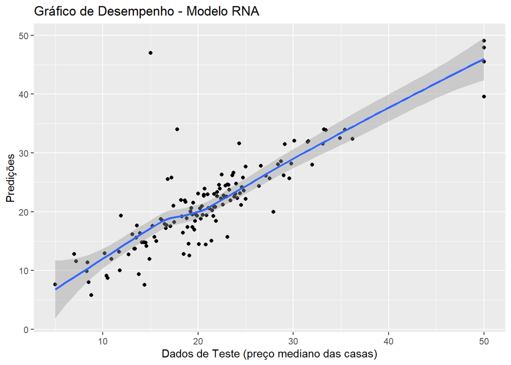

```r
# Plot dos erros
chart <- ggplot(df_RNA_pred, aes(x = dados_teste,y = RNA_pred)) +
            geom_point() +
            stat_smooth() +
            xlab('Dados de Teste (preço mediano das casas)') +
            ylab('Predições')  +
            ggtitle("Gráfico de Desempenho - Modelo RNA")
chart
```

```r
#plotly::ggplotly(chart)
```